# From Accidents to Misuse: How Reported AI Harm Has Changed Since 2015

Author

Abhiyankar Sindhu

Published

October 27, 2026

## 1. Business Understanding

### Stakeholder and Research Question

This report is written for policy and resource-allocation leads at the **UK AI Security Institute (AISI)** and similar regulatory bodies. Public-sector AI regulators face a practical budget question: should oversight resources go primarily towards engineering reliability standards that prevent AI systems from failing by accident, or towards misuse prevention, detection, and enforcement that stop people from abusing AI tools deliberately?

To help inform that balance, this analysis investigates the following question:

> **Since 2015, has the balance of reported AI incidents shifted from AI systems failing by accident towards people deliberately misusing AI, and which types of harm drove the change?**

### Success Criteria

Before inspecting the results, three measurable criteria were set to evaluate whether the evidence supports a clear policy recommendation:

1. **Magnitude of the shift in intent:** Measure the percentage share of intentional incidents before 2022 (`2015–2021`) versus from 2022 onwards (`2022–2025`), and determine whether the increase exceeds a substantive threshold of **15 percentage points**.
2. **Primary risk domain driver:** Identify which specific risk domain(s) and subdomain(s) account for the majority of the change between the two periods.
3. **Robustness to data constraints:** Assess whether the observed shift remains larger than the share of unclassified recent incidents and evaluate how media reporting bias affects the conclusion.

## 2. Data Understanding

### Data Source and Structure

The dataset comes from the **AI Incident Database (AIID)**, maintained by the Responsible AI Collaborative, which indexes real-world harms and near-misses involving artificial intelligence systems reported in news media and public records. Each row represents one distinct incident (which may be covered by multiple news articles, recorded in `report_count`). In addition to incident dates and descriptions, records are categorised using the **MIT AI Risk Repository taxonomy**, which assigns an `Intent` (`Intentional`, `Unintentional`, or `Other`), a high-level `Risk Domain`, and a narrower `Risk Subdomain`.

The raw export contains **1734 incidents** across **59 columns**, covering incidents dated from **1983 to 2026**. Rather than keeping all 59 variables—many of which are sparse technical fields—this analysis selects eight core columns: `incident_id`, `year`, `title`, `report_count`, `risk_domain`, `risk_subdomain`, `responsible_entity`, and `intent`.

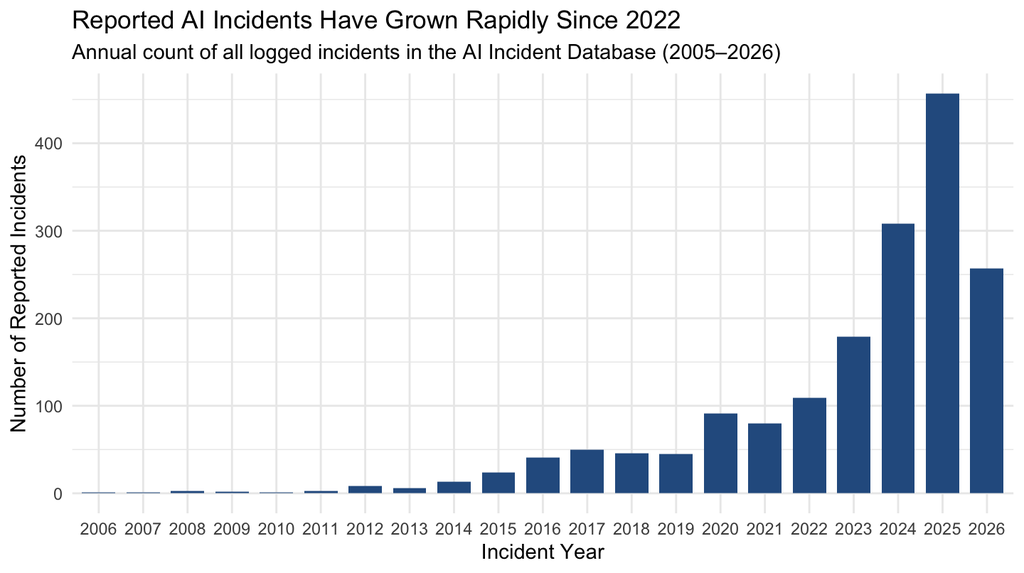

Figure 1: Total reported AI incidents per year in the raw database (2005–2026). Pre-2005 years have 0 to 1 incident per year and are omitted from the axis for readability.

### Initial Exploration and Data Quality Issues

As shown in Figure 1, the total number of logged incidents rises steeply over time, especially after 2022. Because total volume grows so rapidly, comparing raw counts of intentional incidents across years would be misleading: any category could appear to grow simply because the database collects more reports each year. For that reason, the main analysis compares **within-year and within-period percentage shares** rather than raw counts.

Inspecting the selected columns also reveals five data quality constraints that directly affect how the data must be prepared (Table 1):

1. **Sparse early records:** Across the entire span from 1983 to 2014, there are only **47 incidents** in total. In years with only one or two incidents, a single event swings the annual intentional share by 50 or 100 percentage points.
2. **Incomplete 2026 data:** The year 2026 contains **257 incidents** because data collection for the current year was still in progress when the snapshot was exported.
3. **Unclassified incidents in recent years:** Exactly **238 incidents (13.7%)** have missing (`NA`) values for `risk_domain` and `intent` (Table 1). These unclassified records are concentrated in the most recent logs: in 2025 alone, **47 of 457 incidents (10.3%)** had not yet received an MIT taxonomy classification.
4. **Ambiguous `"Other"` intent:** A small subset of **21 incidents** is coded as `"Other"` rather than `"Intentional"` or `"Unintentional"`, where intent could not be cleanly established.
5. **Media reporting bias:** Because AIID relies on publicly reported articles, it measures *reported* AI harm rather than all occurring harm. High-profile scams, deepfakes, or autonomous vehicle crashes attract news coverage more readily than quiet internal software failures.

Table 1: Missing value counts and percentages across the eight selected analysis columns in the raw dataset.

| Column Name | Missing Rows (n) | Missing Share (%) |
| --- | --- | --- |
| incident_id | 0 | 0.0 |
| year | 0 | 0.0 |
| title | 0 | 0.0 |
| report_count | 0 | 0.0 |
| risk_domain | 238 | 13.7 |
| risk_subdomain | 239 | 13.8 |
| responsible_entity | 238 | 13.7 |
| intent | 238 | 13.7 |

## 3. Data Preparation

To address the quality issues identified in Section 2, four sequential preparation steps were applied to construct the final analysis dataset (`incidents_clean`):

1. **Filter to complete years (`2015–2025`):** Rows before 2015 (47 incidents) and rows from the incomplete 2026 year (257 incidents) were removed, reducing the dataset by **304 rows** (from 1734 to 1430).
   - *Justification and alternative:* Starting in 2015 guarantees at least 20 classified incidents per year so annual proportions are stable. We considered starting in 2018 (when annual volume exceeds 40), which would reduce noise further, but doing so would discard three years of baseline data from the pre-generative-AI period.
2. **Remove unclassified incidents:** Rows missing `intent` or `risk_domain` were dropped, removing **81 rows** and leaving **1349 classified incidents** in `2015–2025`.
   - *Justification, assumption, and limitation:* An alternative was to keep missing rows as an `"Unclassified"` category on the charts. However, because `NA` reflects an administrative backlog in tagging recent 2025 submissions rather than a distinct type of AI intent, including `NA` in the denominator would artificially depress both intentional and unintentional shares in 2025. Dropping them assumes that unclassified 2025 incidents have a similar intent mix to classified 2025 incidents; we test the sensitivity of this assumption in Section 5.
3. **Exclude `"Other"` intent:** The **15 incidents** coded as `"Other"` within `2015–2025` were excluded so `intent` forms a direct binary comparison (`Intentional` vs `Unintentional`). This yields a final clean dataset of **1334 incidents** (**76.9%** of the raw database).
4. **Create the `period` split and shorten category labels:** Incidents were grouped into two periods: **`2015-2021 (Pre-2022)`** and **`2022-2025 (2022 Onwards)`**. Long MIT domain names (such as `"AI system safety, failures, and limitations"`) were shortened to readable factor labels (such as `"System Safety & Failures"`), ordered by overall volume.
   - *Justification and alternative:* Splitting at 2022 captures the commercial mainstreaming of generative text, image, and voice models (such as Stable Diffusion, Midjourney, and ChatGPT in 2022). An alternative split at 2023 (the first full calendar year after ChatGPT’s November 2022 release) was considered, but the annual data in Section 4 shows that the upward inflection in deliberate misuse already begins during 2022.

## 4. Analysis

### Analytical Approach and Assumptions

The analysis proceeds in three steps matched to the success criteria: first, tracking the annual share of intentional versus unintentional incidents from 2015 to 2025; second, comparing pooled intentional shares across the pre-2022 and post-2022 periods; and third, breaking down risk domains and subdomains to see which specific harms account for the shift. Using relative proportions assumes that MIT taxonomy annotators applied the definitions of `Intentional` and `Risk Domain` consistently across older and newer incidents. Because the MIT AI Risk Repository was applied systematically across the historical archive, this assumption is reasonable for classified records.

### Shift from Unintentional Failures to Intentional Misuse

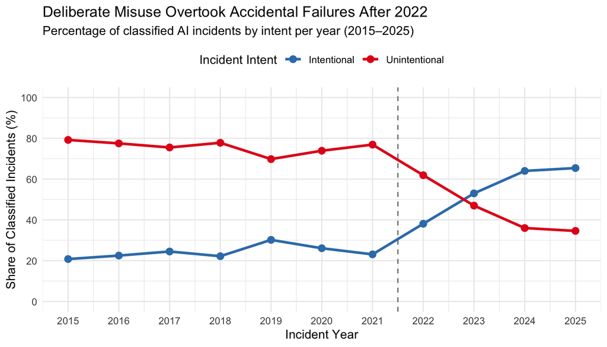

Figure 2: Annual share of classified AI incidents by intent (2015–2025). The dashed vertical line marks the start of the 2022–2025 period.

Figure 2 shows a clear structural reversal in reported AI harm. Between 2015 and 2021, AI incidents were overwhelmingly accidental: the intentional share remained between **21% and 30%** across most of the period (standing at **20.8%** in 2015 and **23.1%** in 2021). In 2022, the intentional share rose to **38.1%**, before crossing the majority threshold in 2023 (**53%**) and reaching **65.4%** in 2025.

Table 2: Comparison of classified AI incidents and intentional share before and after 2022.

| Period | Classified Incidents | Intentional Incidents | Unintentional Incidents | Intentional Share (%) |
| --- | --- | --- | --- | --- |
| 2015-2021 (Pre-2022) | 367 | 90 | 277 | 24.5 |
| 2022-2025 (2022 Onwards) | 967 | 579 | 388 | 59.9 |

Pooling the data into the two periods confirms the scale of this change (Table 2). Across `2015–2021`, only **24.5%** of classified incidents were intentional. Across `2022–2025`, the intentional share rose to **59.9%**—an increase of **35.4 percentage points**, which is more than double the 15-percentage-point threshold set in Criterion 1.

### Which Risk Domains Drove the Change?

To test whether this shift occurred evenly across all categories or was driven by specific harms, Figure 3 compares the distribution of MIT Risk Domains before and after 2022.

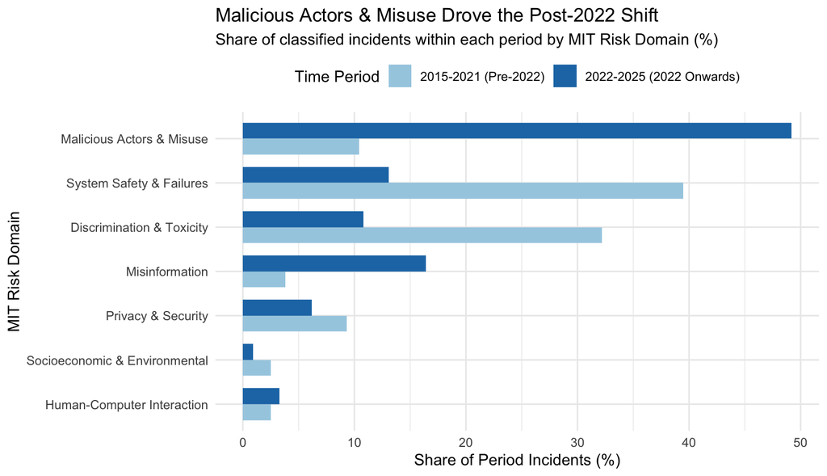

Figure 3: Share of classified AI incidents across MIT Risk Domains in 2015–2021 versus 2022–2025.

As Figure 3 illustrates, the shift was heavily concentrated in a single domain:

- **Malicious Actors & Misuse** jumped from **10.4%** of classified incidents in `2015–2021` to **49.2%** in `2022–2025` (an increase of **38.8 percentage points**).
- Over the same timeframe, the relative share of **System Safety & Failures** fell from **39.5%** to **13.1%**, and **Discrimination & Toxicity** declined from **32.2%** to **10.8%**. Important to note for managers: accidental safety failures did not disappear in absolute terms, but malicious misuse grew so rapidly after 2022 that it came to dominate the overall incident mix.

Table 3: Breakdown of incidents within the ‘Malicious Actors & Misuse’ domain by MIT Risk Subdomain (2015–2025).

| Risk Subdomain | Incidents | Share of Misuse (%) |
| --- | --- | --- |
| Fraud, scams, and targeted manipulation | 369 | 71.8 |
| Disinformation, surveillance, and influence at scale | 130 | 25.3 |
| Cyberattacks, weapon development or use, and mass harm | 15 | 2.9 |

Drilling into the **514 incidents** classified under `Malicious Actors & Misuse` (Table 3) pinpoints the exact operational driver: **Fraud, scams, and targeted manipulation** accounts for **369 incidents (71.8%)** of the entire domain. These incidents largely involve voice-cloning scams, non-consensual deepfake imagery, financial impersonation frauds, and targeted disinformation campaigns enabled by accessible generative AI tools.

## 5. Evaluation

### Assessment Against Success Criteria

1. **Criterion 1 (Shift > 15 percentage points) — Met:** The share of intentional incidents increased from **24.5%** in `2015–2021` to **59.9%** in `2022–2025`, a jump of **35.4 percentage points** (Table 2).
2. **Criterion 2 (Identify driving risk domain and subdomain) — Met:** The `Malicious Actors & Misuse` domain expanded by **38.8 percentage points** between periods (Figure 3), and **71.8%** of that domain is driven by a single subdomain: **Fraud, scams, and targeted manipulation** (Table 3).
3. **Criterion 3 (Robustness to unclassified incidents and bias) — Partially met (conclusive direction, uncertain exact magnitude):** Even though **10.3%** of 2025 logs remain unclassified, the post-2022 shift is already well established in fully classified years like 2023 (**53%** intentional). However, media reporting bias means the exact percentages reflect *newsworthy* harms rather than a census of all AI failures.

### Limitations and Next Steps in CRISP-DM

- **Media salience bias:** Journalists are more likely to report dramatic deepfake scams involving celebrities, politicians, or schools than routine algorithmic bias in credit scoring or hospital scheduling. Consequently, the **59.9%** post-2022 intentional share likely overstates the prevalence of misuse relative to silent technical failures.
- **Classification backlog in 2025:** Dropping the 81 unclassified rows from `2015–2025` could bias the 2025 figure if editors classify straightforward fraud stories faster than complex technical failures.
- **Recommended next iteration:** In a follow-up CRISP-DM cycle, we would incorporate `report_count` to weight or filter incidents by media attention, cross-check `responsible_entity` (`Human` vs `AI`) against `intent`, and re-run the 2025 scripts once the remaining 47 incidents receive MIT taxonomy labels.

## 6. Deployment and Communication

### Executive Summary for the UK AI Security Institute

For policy and resource-allocation leads at the UK AI Security Institute, the evidence in the AI Incident Database shows a fundamental change in the nature of reported AI harm. Prior to 2022, roughly three-quarters of logged AI incidents were unintentional failures—such as flawed content filters, biased hiring or policing algorithms, and autonomous vehicle collisions. Since 2022, deliberate human misuse has overtaken accidental system failure, rising from **24.5%** of classified incidents in `2015–2021` to **59.9%** in `2022–2025` (and reaching **65.4%** in 2025). Nearly three-quarters (**71.8%**) of all malicious misuse incidents involve **fraud, scams, and targeted manipulation**.

While engineering safety evaluations remain necessary—because accidental failures still occur alongside misuse—technical reliability testing alone will not address the fastest-growing source of public AI harm. Regulatory effort should expand downstream safeguards aimed at deliberate abuse: mandatory provenance and watermarking standards for synthetic audio and video, rapid takedown and abuse-monitoring requirements for generative AI providers, and closer coordination with financial fraud and law-enforcement agencies.